# Análisis Exploratorio de Datos (EDA)

En esta sección del notebook se realiza un análisis exploratorio para el dataset de detección de obstáculos en interiores conformado, abarcando los siguientes pasos:

```python
# Auto-reload: recarga módulos automáticamente al detectar cambios en disco
%load_ext autoreload
%autoreload 2

# Librerías
import os
import sys
import json
import pandas as pd
import seaborn as sns
import matplotlib.pyplot as plt
import numpy as np
import cv2
import random
import hashlib
import yaml
from pycocotools.coco import COCO
from sklearn.cluster import KMeans

# Rutas base
base_dir = "/Users/admin/Documents/TFM_UNIR/01_ING_DATOS"
dataset_path = os.path.join(base_dir, "Datasets", "dataset_maestro_unificado")

# Añadir path de utilidades
src_path = os.path.join(base_dir, "src")
if src_path not in sys.path:
    sys.path.insert(0, src_path)
from utils_eda import *

# Directorio de salida para guardar reportes
output_dir = os.path.join(base_dir, "Reports")
```

## Paso 1: Unificación de Datasets Base

Este paso inicial del tratamiento de datos se realizó para unificar los 15 datasets utilizados como fuente de datos. El objetivo es consolidar las imágenes y etiquetas en un único Dataset Maestro con un mapeo de clases unificado, en formato YOLO, serializando las imágenes como img_000001, img_000002, ...

El proceso realizado es:

1. Lee data.yaml de cada dataset → extrae clases locales.
2. Normaliza nombres de clases (lowercase + singular + excepciones).
3. Construye mapeo global unificado de clases.
4. Mueve imágenes y reescribe labels con el nuevo class_id.
5. Genera data.yaml unificado + log de trazabilidad + análisis de distribución.

Para lo cual fue generado el script `Union_dataset.py` y entrega el dataset curado en la carpeta `./01_ING_DATOS/Datasets/dataset_maestro_unificado`. Los datasets utilizados para la creación de este Dataset Maestro son:

```
DATASETS = [
    "Roboflow_dataset10-yolo26",
    "Roboflow_Dataset11-yolo26",
    "Roboflow_Dataset12-yolo26",
    "Roboflow_Dataset13-stair-yolo26",
    "Roboflow_Dataset14-stair-yolo26",
    "Roboflow_Dataset15-MyHome-yolo26",
    "Roboflow_Dataset8_IndoorObstacleDetection-yolo26",
    "Roboflow_Door-Detection-yolo26",
    "Roboflow_DoorDetection-yolo26",
    "Roboflow_DoorsOD-yolo26",
    "Roboflow_ObstacleUnique-yolo26",
    "Roboflow_obstacle-avoidnace-yolo26",
    "Roboflow_obstacle-door-person-yolo26",
    "Roboflow_obstacle-person2-yolo26",
    "Roboflow_obstacle-yolo26",
]
```

```
💾 Figura guardada: /Users/admin/Documents/TFM_UNIR/01_ING_DATOS/Reports/01_Distribution_Dataset_Maestro_Unificado.png.png
```

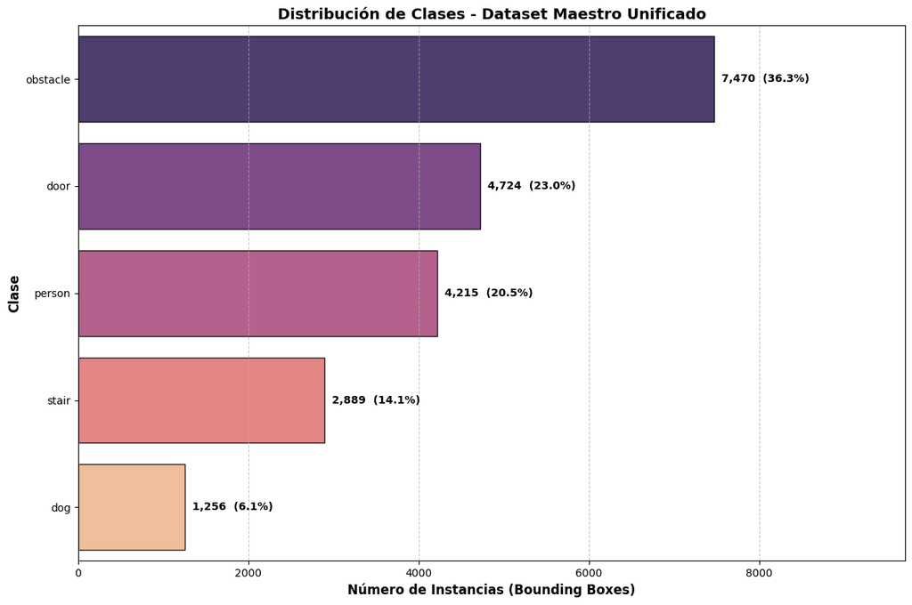

```
--- Distribución de Clases (YOLO) ---
| Class    |   Count |
|:---------|--------:|
| obstacle |    7470 |
| door     |    4724 |
| person   |    4215 |
| stair    |    2889 |
| dog      |    1256 |
💾 Tabla guardada: /Users/admin/Documents/TFM_UNIR/01_ING_DATOS/Reports/01_Distribution_Dataset_Maestro_Unificado.png.csv
```

```python
# 1. Visualización de la Distribución de Clases para el Dataset Maestro Unificado
df = plot_yolo_class_distribution(
    dataset_path,
    output_dir=output_dir,
    title="Distribución de Clases - Dataset Maestro Unificado",
    filename="01_Distribution_Dataset_Maestro_Unificado.png"
)
```

## Paso 2: Análisis Técnico del Dataset

Antes de analizar el contenido semántico del dataset, es fundamental verificar la calidad técnica de los datos a nivel de archivos e imágenes.

**Dataset:** `dataset_maestro_unificado` (dataset unificado, sin división en splits train/valid/test).

**Objetivos:**

1. **Analizar resoluciones:** Verificar consistencia de dimensiones de imágenes.
2. **Sanity checks de integridad:**
   - Archivos corruptos o ilegibles
   - Formatos incorrectos (RGBA, grayscale cuando se espera RGB)
   - Duplicados exactos dentro del dataset (contamination)
3. **Estadísticas de píxeles:** Calcular **mean y std por canal RGB** para normalización del modelo.
4. **Distribución de intensidad:** Analizar histogramas RGB para identificar necesidades de augmentation (brightness, contrast).

**Impacto en el entrenamiento:**

- Imágenes con resoluciones inconsistentes requieren redimensionamiento uniforme.
- Duplicados pueden causar overfitting artificial.
- Channel statistics son **críticas** para la normalización en PyTorch/TensorFlow.

```python
# Cargar dataset YOLO como objeto COCO
coco, img_dir = load_yolo_as_coco(dataset_path)
splits = {'all': coco}
img_dir_map = {'all': img_dir}
print(f"✅ Dataset unificado cargado: {len(coco.getImgIds())} imágenes, {len(coco.getAnnIds())} anotaciones")

# Variables de interés para análisis de geometría y complejidad
target_cat_ids = coco.getCatIds()
id_to_name = {cat['id']: cat['name'] for cat in coco.loadCats(target_cat_ids)}
print(f"🏷️  Clases encontradas: {list(id_to_name.values())}")

# Asignar colores automáticamente a cada clase
_color_pool = [
    (255, 0, 0),      # Rojo
    (0, 255, 0),      # Verde
    (0, 0, 255),      # Azul
    (255, 255, 0),    # Cyan/Amarillo
    (255, 0, 255),    # Magenta
    (0, 255, 255),    # Amarillo (BGR)
]
class_colors = {name: _color_pool[i % len(_color_pool)] for i, name in enumerate(id_to_name.values())}
print(f"🎨 Colores asignados: {class_colors}")
```

```
loading annotations into memory...
Done (t=0.03s)
creating index...
index created!
✅ Dataset YOLO cargado como COCO:
   📂 Imágenes: 10386
   📝 Anotaciones: 20554
   🏷️  Categorías: ['obstacle', 'dog', 'person', 'stair', 'door']
✅ Dataset unificado cargado: 10386 imágenes, 20554 anotaciones
🏷️  Clases encontradas: ['obstacle', 'dog', 'person', 'stair', 'door']
🎨 Colores asignados: {'obstacle': (255, 0, 0), 'dog': (0, 255, 0), 'person': (0, 0, 255), 'stair': (255, 255, 0), 'door': (255, 0, 255)}
```

```
🎨 Generando histogramas de distribución de píxeles...
💾 Histogramas guardados: /Users/admin/Documents/TFM_UNIR/01_ING_DATOS/Reports/02_rgb_histograms.png
```

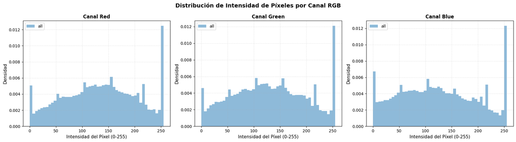

```python
# 2. Visualizar distribución de intensidad de píxeles por canal RGB
plot_channel_histograms(splits, base_dir, sample_size=100, img_dir_map=img_dir_map,
                        output_dir=output_dir, filename='02_rgb_histograms', title='Distribución de Intensidad de Píxeles por Canal RGB')
```

```python
# 3. Calcular estadísticas de canales RGB para normalización del modelo
df_pixel_stats = calculate_pixel_statistics(splits, base_dir, sample_size=100,
                                            img_dir_map=img_dir_map,
                                            output_dir=output_dir, filename='03_channel_stats')
```

```
📊 Calculando estadísticas de canales RGB...
   ALL: RGB mean=[0.5431, 0.5231, 0.4982], std=[0.2607, 0.2629, 0.2727]
💾 Estadísticas guardadas: /Users/admin/Documents/TFM_UNIR/01_ING_DATOS/Reports/03_channel_stats.csv
```

[output not shown]

[output cut: 317 more lines]

[output not shown]

|  | hash | split | image_id | filename | duplicate_count |
| --- | --- | --- | --- | --- | --- |
| 0 | 7b957d3e6e21b589b244a1042dc51bc8 | all | 259 | img_000259.jpg | 2 |
| 1 | 7b957d3e6e21b589b244a1042dc51bc8 | all | 4390 | img_004390.jpg | 2 |
| 2 | 8db93b0ed5f068d8503a887134f9bca1 | all | 260 | img_000260.jpg | 2 |
| 3 | 8db93b0ed5f068d8503a887134f9bca1 | all | 4391 | img_004391.jpg | 2 |
| 4 | 2d8b28b241f3e4f4258ed7180b9495a9 | all | 282 | img_000282.jpg | 2 |

```
🔍 Mostrando 8 imágenes duplicadas de 743 encontradas
💾 Figura guardada: /Users/admin/Documents/TFM_UNIR/01_ING_DATOS/Reports/04b_duplicate_samples.png
```

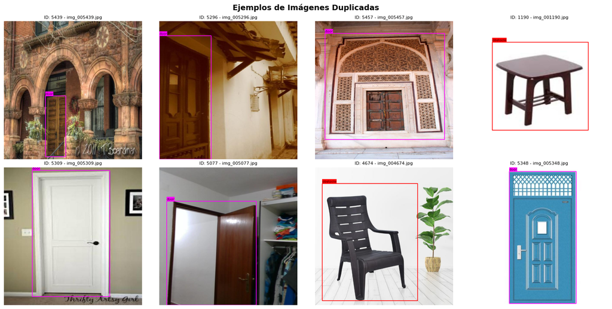

```python
# 4. Detectar imágenes duplicadas dentro del dataset usando hash MD5
df_duplicates = detect_duplicates_across_splits(splits, base_dir, img_dir_map=img_dir_map,
                                                output_dir=output_dir, filename='04_duplicates')

display(df_duplicates.head())

# Visualizar muestra de imágenes duplicadas
if len(df_duplicates) > 0:
    dup_img_ids = df_duplicates['image_id'].unique().tolist()
    sample_size = min(8, len(dup_img_ids))
    sample_dup = random.sample(dup_img_ids, sample_size)
    print(f"🔍 Mostrando {sample_size} imágenes duplicadas de {len(dup_img_ids)} encontradas")
    visualize_sample(coco, target_cat_ids, id_to_name, class_colors, img_dir,
                    img_ids=sample_dup, output_dir=output_dir, filename='04b_duplicate_samples', title='Ejemplos de Imágenes Duplicadas')
else:
    print("✅ No hay imágenes duplicadas para visualizar")
```

```python
# 5. Verificar integridad de archivos de imagen
df_integrity = check_file_integrity(splits, base_dir, img_dir_map=img_dir_map,
                                    output_dir=output_dir, filename='05_integrity_check')
```

```
✅ Verificación de Integridad: SIN PROBLEMAS
   Todas las imágenes son válidas y legibles (RGB)
```

```
💾 Figura guardada: /Users/admin/Documents/TFM_UNIR/01_ING_DATOS/Reports/06_resolution_scatter.png
💾 Tabla de resoluciones guardada: /Users/admin/Documents/TFM_UNIR/01_ING_DATOS/Reports/06_resolution_scatter_table.csv
```

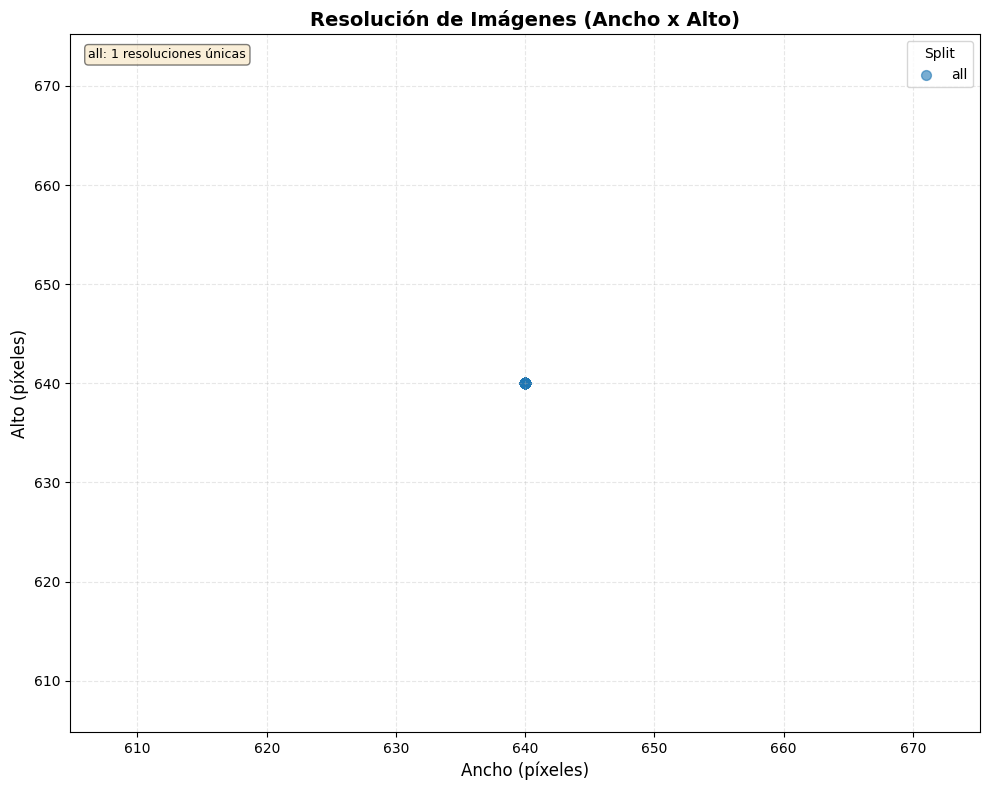

```python
# 6. Extraer dimensiones de todas las imágenes
df_dimensions = get_image_dimensions(splits)
plot_resolution_scatter(df_dimensions, output_dir=output_dir, filename='06_resolution_scatter', title='Resolución de Imágenes (Ancho x Alto)')
```

## Paso 3: Análisis de Distribución de Clases

En esta etapa se decide qué clases se conservan basándose en su representatividad y relevancia estadística.

- **Conteo de Instancias por Categoría:**
  - **Objetivo:** Identificar clases "minoritarias" que el modelo no aprenderá bien.
- **Imágenes por Categoría vs. Objetos por Categoría:**
  - **Objetivo:** Determinar si una clase está bien distribuida en el dataset o si aparece concentrada en pocas imágenes.
- **Matriz de Co-ocurrencia:**
  - **Objetivo:** Analizar qué objetos aparecen juntos para entender el contexto (ej. la relación entre "Mesa" y "Silla").

```python
# Usar dataset unificado completo para análisis de clases
print(f"✅ Usando dataset unificado para análisis de clases: {len(coco.getImgIds())} imágenes")
```

```
✅ Usando dataset unificado para análisis de clases: 10386 imágenes
```

```
💾 Figura guardada: /Users/admin/Documents/TFM_UNIR/01_ING_DATOS/Reports/07_category_distribution.png
```

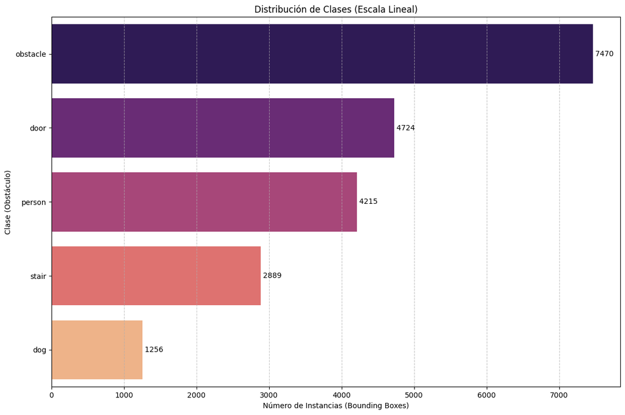

```
--- Tabla de Distribución ---
| Category   |   Count |
|:-----------|--------:|
| obstacle   |    7470 |
| door       |    4724 |
| person     |    4215 |
| stair      |    2889 |
| dog        |    1256 |
💾 Tabla guardada: /Users/admin/Documents/TFM_UNIR/01_ING_DATOS/Reports/07_category_distribution.csv
```

```python
# 7. Obtener categorías y conteos
cat_ids = [cat['id'] for cat in coco.loadCats(coco.getCatIds())]
df_counts = get_category_distribution(coco)
plot_category_distribution(df_counts, scale_type='linear', palette='magma',
                          output_dir=output_dir, filename='07_category_distribution', title='Distribución de Clases (Escala Lineal)')
```

```
💾 Figura guardada: /Users/admin/Documents/TFM_UNIR/01_ING_DATOS/Reports/08_image_object_density.png
```

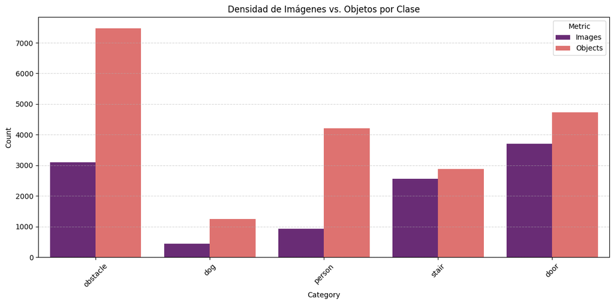

```python
# 8. Obtener Densidad de Imágenes VS. Objetos
df_density, active_cat_ids = calculate_image_object_density(coco, cat_ids)
plot_image_object_density(df_density, palette='magma',
                         output_dir=output_dir, filename='08_image_object_density', title="Densidad de Imágenes vs. Objetos por Clase")
```

```
💾 Figura guardada: /Users/admin/Documents/TFM_UNIR/01_ING_DATOS/Reports/09_cooccurrence_matrix.png
💾 Matriz guardada: /Users/admin/Documents/TFM_UNIR/01_ING_DATOS/Reports/09_cooccurrence_matrix.csv
```

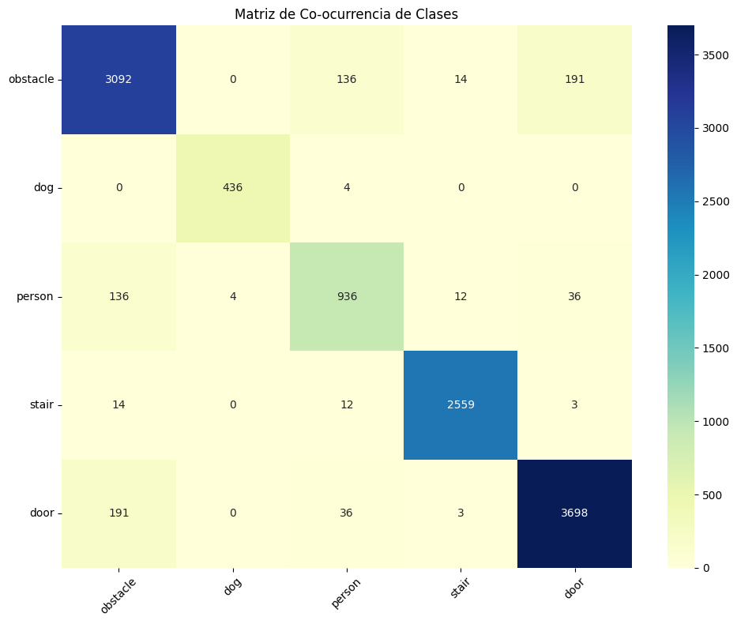

```python
# 9. Obtener Matriz de Co-ocurrencia
co_occurrence_matrix, cat_labels = calculate_cooccurrence_matrix(coco, active_cat_ids)
plot_cooccurrence_matrix(co_occurrence_matrix, cat_labels, cmap='YlGnBu',
                        output_dir=output_dir, filename='09_cooccurrence_matrix', title='Matriz de Co-ocurrencia de Clases')
```

```
--- Ratio de Densidad (Promedio de objetos por imagen donde aparece la clase) ---
| Category   |   Images |   Objects |   Ratio |
|:-----------|---------:|----------:|--------:|
| person     |      936 |      4215 |  4.5032 |
| dog        |      436 |      1256 |  2.8807 |
| obstacle   |     3092 |      7470 |  2.4159 |
| door       |     3698 |      4724 |  1.2774 |
| stair      |     2559 |      2889 |  1.129  |
💾 Figura guardada: /Users/admin/Documents/TFM_UNIR/01_ING_DATOS/Reports/10_density_ratio.png
💾 Tabla guardada: /Users/admin/Documents/TFM_UNIR/01_ING_DATOS/Reports/10_density_ratio.csv
```

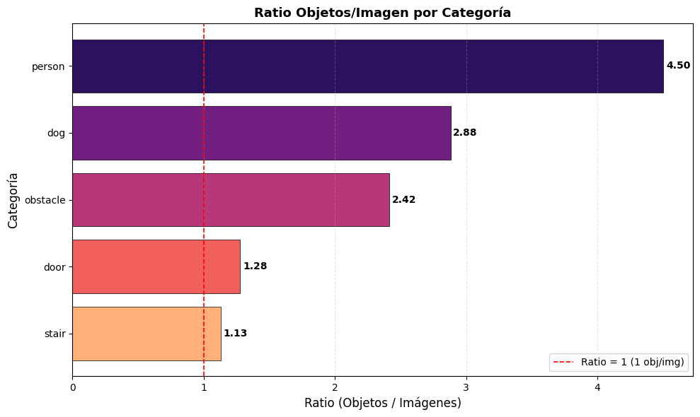

```python
# 10. Calcular ratio Objetos/Imagen por categoría
df_ratio = calculate_and_plot_density_ratio(df_density, palette='magma',
                                            output_dir=output_dir, filename='10_density_ratio', title='Ratio Objetos/Imagen por Categoría')
```

## Paso 4: Análisis Geométrico de Bounding Boxes

- **Distribución de Tamaños (Área):**
  - **Objetivo:** Clasificar objetos en **Pequeños**, **Medianos** y **Grandes** (Estándar COCO).
- **Relación de Aspecto (Aspect Ratio):**
  - **Objetivo:** Graficar ancho vs. alto.
- **Posición Espacial (Heatmap):**
  - **Objetivo:** Mapa de calor de los centros de las cajas.
- **Optimización de Anchors:**
  - **Objetivo:** Calcular anchors óptimos usando K-Means clustering sobre dimensiones de bboxes.

```python
# 11. Extraer geometría usando función modular
df_geo = extract_bbox_geometry(coco, target_cat_ids,
                               output_dir=output_dir, filename='11_bbox_geometry')
```

```
📐 Geometría de Bounding Boxes extraída: 20554 anotaciones
| Category   |   Count |   Area_mean |   Area_median |   Ratio_mean |   Ratio_std |
|:-----------|--------:|------------:|--------------:|-------------:|------------:|
| dog        |    1256 |     64625   |       35662.5 |         4.54 |       11.48 |
| door       |    4724 |     89271.7 |       78081.5 |         0.57 |        4.35 |
| obstacle   |    7470 |     52906.9 |       27156   |         2.07 |        9.33 |
| person     |    4215 |     31314.2 |       15867   |         1.28 |        5.25 |
| stair      |    2889 |    188734   |      166793   |         1.17 |        0.69 |
💾 Geometría guardada: /Users/admin/Documents/TFM_UNIR/01_ING_DATOS/Reports/11_bbox_geometry.csv
💾 Resumen guardado: /Users/admin/Documents/TFM_UNIR/01_ING_DATOS/Reports/11_bbox_geometry_summary.csv
```

```
💾 Figura guardada: /Users/admin/Documents/TFM_UNIR/01_ING_DATOS/Reports/12_size_distribution.png
```

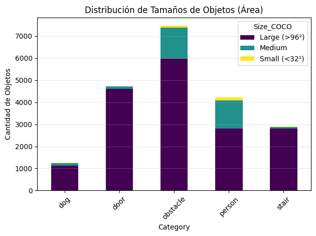

```
--- Porcentaje de Tamaños por Clase ---
| Category   |   Large (>96²) |   Medium |   Small (<32²) |
|:-----------|---------------:|---------:|---------------:|
| dog        |          89.65 |     9.63 |           0.72 |
| door       |          97.42 |     2.33 |           0.25 |
| obstacle   |          79.83 |    18.96 |           1.22 |
| person     |          66.38 |    30.34 |           3.27 |
| stair      |          96.85 |     2.98 |           0.17 |
💾 Tabla guardada: /Users/admin/Documents/TFM_UNIR/01_ING_DATOS/Reports/12_size_distribution_percentages.csv
```

```python
# 12. Visualizar la Distribución de Tamaños COCO
plot_size_distribution(df_geo, colormap='viridis',
                     output_dir=output_dir, filename='12_size_distribution', title='Distribución de Tamaños de Objetos (Área)')
```

```
💾 Figura guardada: /Users/admin/Documents/TFM_UNIR/01_ING_DATOS/Reports/13_aspect_ratio.png
```

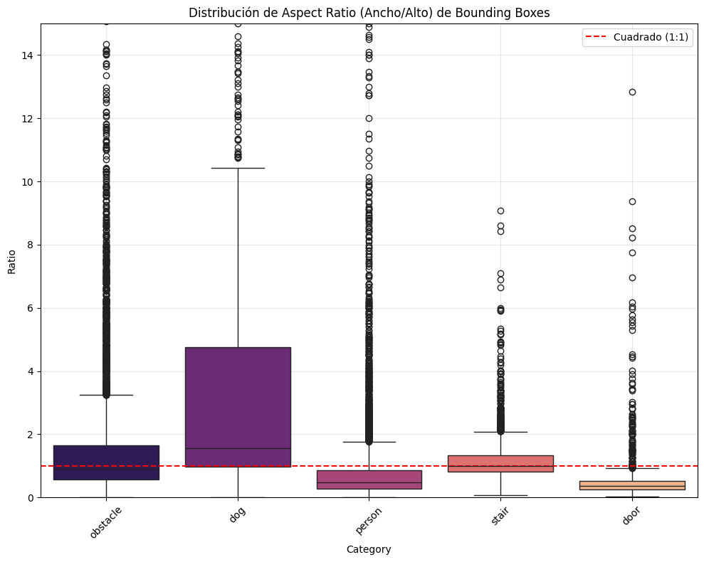

```python
# 13. Visualizar el Aspect Ratio
plot_aspect_ratio(df_geo, palette='magma',
                output_dir=output_dir, filename='13_aspect_ratio', figsize=(10, 8), title='Distribución de Aspect Ratio (Ancho/Alto) de Bounding Boxes')
```

```
💾 Figura guardada: /Users/admin/Documents/TFM_UNIR/01_ING_DATOS/Reports/14_spatial_heatmap.png
```

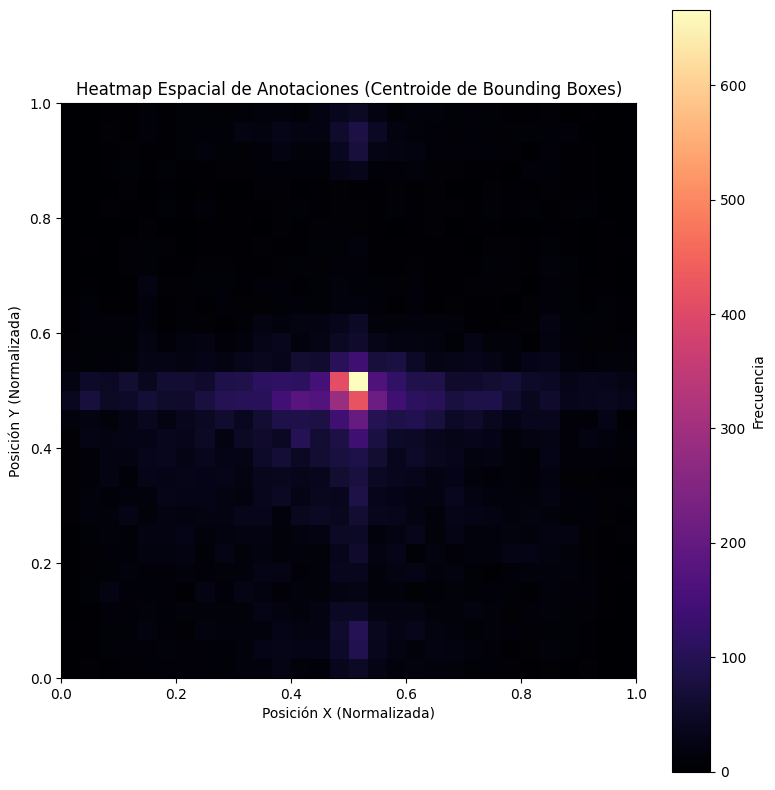

```python
# 14. Visualizar el Heatmap Espacial
plot_spatial_heatmap(df_geo, cmap='magma',
                   output_dir=output_dir, filename='14_spatial_heatmap', title='Heatmap Espacial de Anotaciones (Centroide de Bounding Boxes)')
```

```python
# 15. Extraer dimensiones normalizadas de todos los bboxes
bbox_dims = extract_bbox_dimensions(coco, target_cat_ids)

print(f"\n📦 Total de bounding boxes extraídos: {len(bbox_dims)}")
print(f"   Dimensiones: ancho y alto normalizados [0,1]")
```

```
📦 Total de bounding boxes extraídos: 20554
   Dimensiones: ancho y alto normalizados [0,1]
```

```
🔬 Ejecutando K-Means con 10 clusters sobre 20554 bboxes...
✅ Anchors optimizados calculados
💾 Visualización de anchors guardada: /Users/admin/Documents/TFM_UNIR/01_ING_DATOS/Reports/16_anchor_clusters.png
```

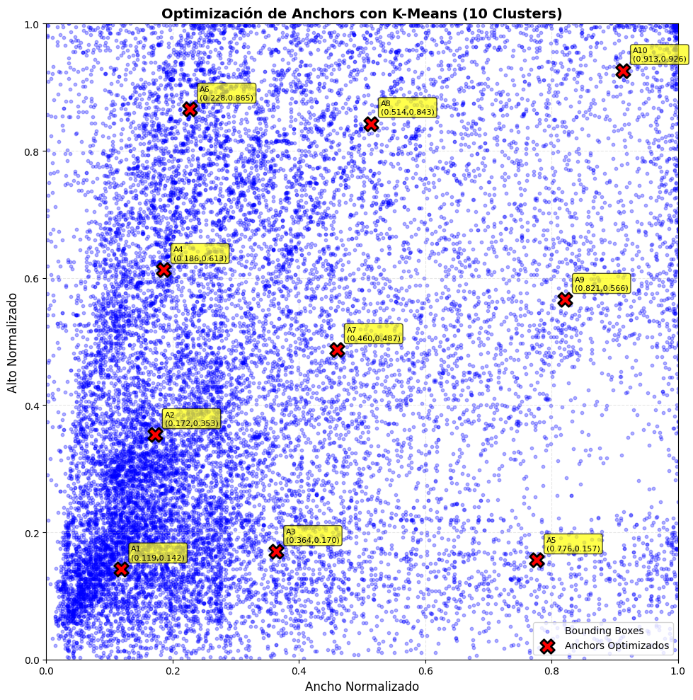

```python
# 16. Calcular y visualizar anchors óptimos usando K-Means
optimal_anchors = kmeans_anchor_optimization(bbox_dims, n_anchors=10, random_state=42)
plot_anchor_clusters(bbox_dims, optimal_anchors, output_dir=output_dir,
                    filename='16_anchor_clusters', title='Optimización de Anchors con K-Means (10 Clusters)')
```

```python
# 17. Exportar configuración YAML con Anchors optimizados
export_yolo_anchors(optimal_anchors, img_size=640, output_dir=output_dir,
                   filename='17_yolo_anchors')
```

```
⚙️  Configuración de Anchors para YOLO:
   Imagen: 640x640
   Anchors P3/8 (pequeños): [[76, 91], [110, 226], [233, 108]]
   Anchors P4/16 (medianos): [[118, 392], [496, 100], [145, 553]]
   Anchors P5/32 (grandes): [[294, 311], [328, 539], [525, 362], [584, 592]]
💾 Configuración YAML guardada: /Users/admin/Documents/TFM_UNIR/01_ING_DATOS/Reports/17_yolo_anchors.yaml
   Usar en modelo: copiar anchors a tu archivo de configuración YOLO
```

## Paso 5: Complejidad de la Escena

Determina la carga computacional y la dificultad técnica del entrenamiento.

- **Objetos por Imagen (Densidad):**
  - **Objetivo:** Histograma de cantidad de objetos por foto.
  - **Impacto:** Imágenes vacías ayudan a reducir falsos positivos; imágenes muy densas requieren más memoria GPU.
- **Superposición (Occlusión):**
  - **Objetivo:** Calcular el **IoU (Intersection over Union)** entre cajas.
  - **Impacto:** Si hay mucha superposición, se requiere un ajuste fino del *Non-Maximum Suppression (NMS)*.

```
Procesando imágenes para calcular IoU y Densidad...
💾 Figura guardada: /Users/admin/Documents/TFM_UNIR/01_ING_DATOS/Reports/17_density_histogram.png
```

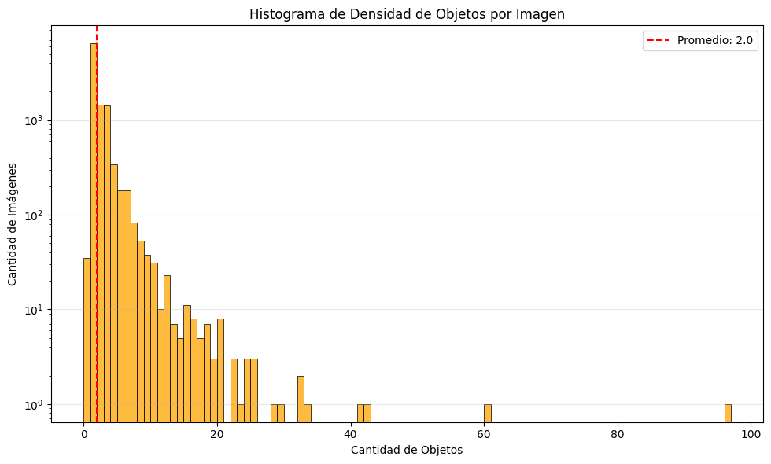

```python
# 17. Visualizar Histograma de Densidad
img_ids = coco.getImgIds()
density_counts, ious = calculate_density_and_iou(coco, target_cat_ids)
plot_density_histogram(density_counts, color='orange',
                     output_dir=output_dir, filename='17_density_histogram', title='Histograma de Densidad de Objetos por Imagen')
```

```
💾 Figura guardada: /Users/admin/Documents/TFM_UNIR/01_ING_DATOS/Reports/18_iou_histogram.png
```

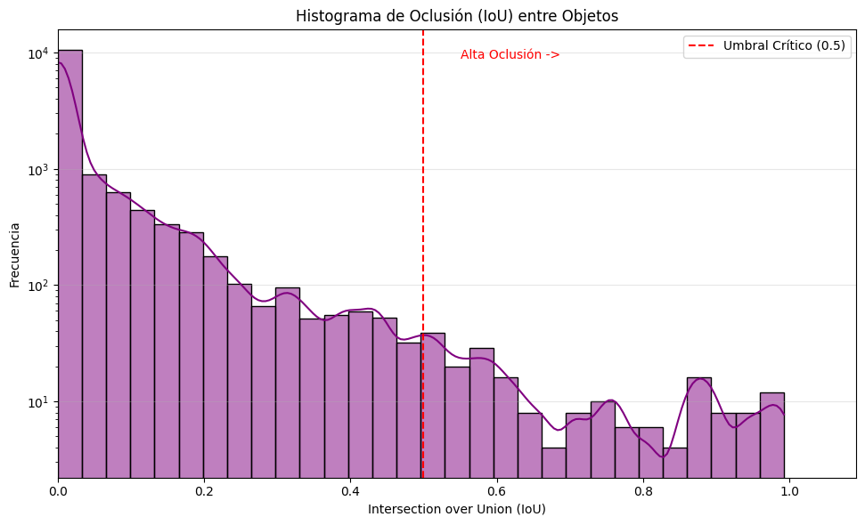

```python
# 18. Visualizar Histograma de Oclusión (IoU)
plot_iou_histogram(ious, color='purple',
                 output_dir=output_dir, filename='18_iou_histogram', title='Histograma de Oclusión (IoU) entre Objetos')
```

```python
# 19. Resumen numérico de Densidad
print_density_stats(img_ids, density_counts,
                  output_dir=output_dir, filename='19_density_stats')
```

```
Total Imágenes Analizadas: 10386
Imágenes Vacías (Background): 35
Promedio de objetos por imagen: 1.98
Máximo de objetos en una imagen: 96
💾 Estadísticas guardadas: /Users/admin/Documents/TFM_UNIR/01_ING_DATOS/Reports/19_density_stats.csv
```

## Paso 6: Inspección Visual Cualitativa (Sanity Check)

Validación manual para asegurar la calidad de la información.

1. **Visualización Randomizada:** Renderizar imágenes con sus etiquetas para confirmar la coherencia de las clases elegidas.
2. **Verificación de "Ruido":** Identificar errores de etiquetado, como cajas que cubren toda la imagen o que son de tamaño minúsculo.

```
💾 Figura guardada: /Users/admin/Documents/TFM_UNIR/01_ING_DATOS/Reports/20_visual_sample_1.png
```

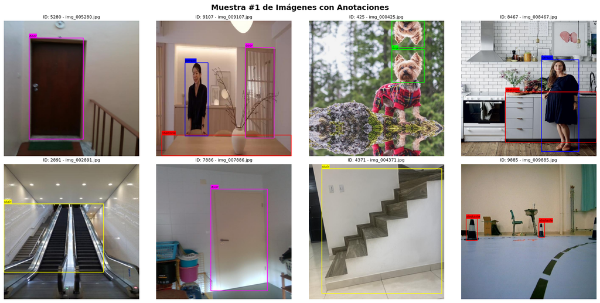

```python
# 20. Visualizar Sample de Imágenes
visualize_sample(coco, target_cat_ids, id_to_name, class_colors, img_dir, num_samples=8,
               output_dir=output_dir, filename='20_visual_sample_1', title='Muestra #1 de Imágenes con Anotaciones')
```

```
💾 Figura guardada: /Users/admin/Documents/TFM_UNIR/01_ING_DATOS/Reports/21_visual_sample_2.png
```

[figure not shown]

```python
# 21. Visualizar Sample de Imágenes
visualize_sample(coco, target_cat_ids, id_to_name, class_colors, img_dir, num_samples=8,
               output_dir=output_dir, filename='21_visual_sample_2', title='Muestra #2 de Imágenes con Anotaciones')
```

```
💾 Figura guardada: /Users/admin/Documents/TFM_UNIR/01_ING_DATOS/Reports/22_visual_sample_3.png
```

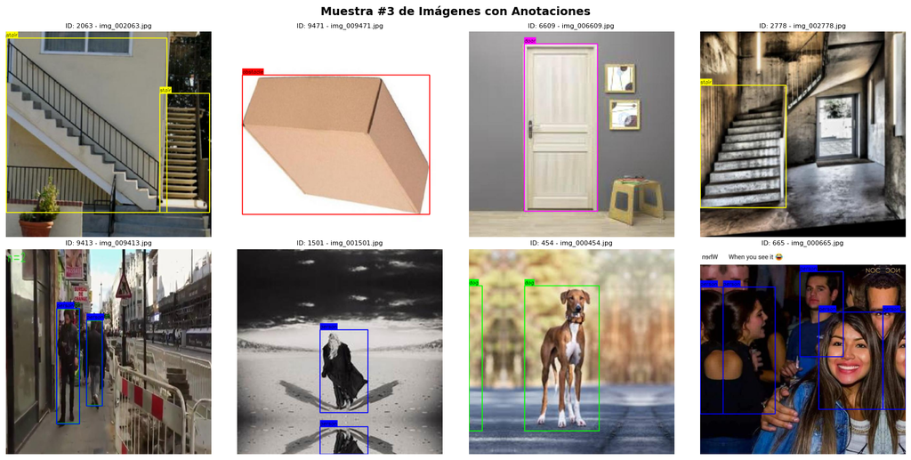

```python
# 22. Visualizar Sample de Imágenes
visualize_sample(coco, target_cat_ids, id_to_name, class_colors, img_dir, num_samples=8,
               output_dir=output_dir, filename='22_visual_sample_3', title='Muestra #3 de Imágenes con Anotaciones')
```

```python
# 23. Detectar anomalías
suspect_tiny, suspect_huge = detect_anomalies(coco, target_cat_ids, id_to_name, min_area=225, max_ratio=0.95,
                                             output_dir=output_dir, filename='23_anomalies')
```

```
--- Iniciando búsqueda de anomalías ---

Resultados del escaneo:
⚠️ Cajas Minúsculas (<15x15px): 36
|    |   img_id | category   | bbox               |   area |
|---:|---------:|:-----------|:-------------------|-------:|
|  0 |     1420 | obstacle   | [639, 222, 1, 186] |    186 |
|  1 |     4403 | obstacle   | [291, 631, 22, 9]  |    198 |
|  2 |     4469 | obstacle   | [222, 639, 88, 1]  |     88 |
|  3 |     4472 | obstacle   | [47, 639, 144, 1]  |    144 |
|  4 |     4489 | obstacle   | [358, 639, 63, 1]  |     63 |

⚠️ Cajas Gigantes (>95.0% imagen): 366
|    |   img_id | category   | bbox              |    ratio |
|---:|---------:|:-----------|:------------------|---------:|
|  0 |      920 | obstacle   | [4, 0, 635, 634]  | 0.982886 |
|  1 |      939 | obstacle   | [0, 6, 639, 634]  | 0.989077 |
|  2 |     1010 | obstacle   | [2, 14, 638, 625] | 0.973511 |
|  3 |     1019 | obstacle   | [0, 3, 640, 635]  | 0.992188 |
|  4 |     1033 | obstacle   | [10, 7, 628, 633] | 0.970518 |
💾 Cajas minúsculas guardadas: /Users/admin/Documents/TFM_UNIR/01_ING_DATOS/Reports/23_anomalies_tiny.csv
💾 Cajas gigantes guardadas: /Users/admin/Documents/TFM_UNIR/01_ING_DATOS/Reports/23_anomalies_huge.csv
```

```
 Ejemplos de imágenes anómalas: con cajas minúsculas
💾 Figura guardada: /Users/admin/Documents/TFM_UNIR/01_ING_DATOS/Reports/24_anomaly_tiny.png
```

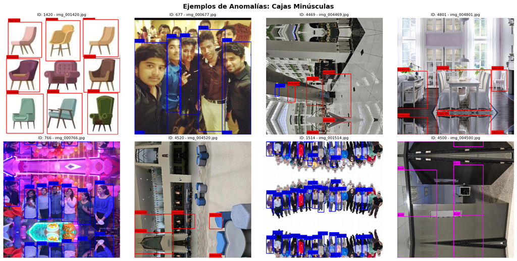

```python
# 24. Visualizar imágenes anómalas de cajas minúsculas
if len(suspect_tiny) > 0:
    print("\n Ejemplos de imágenes anómalas: con cajas minúsculas")
    unique_tiny_ids = list(set([s['img_id'] for s in suspect_tiny]))
    sample_size = min(8, len(unique_tiny_ids))  # Máximo 8 imágenes en grilla 4x2
    sample_tiny = random.sample(unique_tiny_ids, sample_size)

    # Usar grilla de visualize_sample para mostrar múltiples imágenes
    visualize_sample(coco, target_cat_ids, id_to_name, class_colors, img_dir,
                    img_ids=sample_tiny, output_dir=output_dir, filename='24_anomaly_tiny', title='Ejemplos de Anomalías: Cajas Minúsculas')
```

```
 Ejemplos de imágenes anómalas: con cajas gigantes
💾 Figura guardada: /Users/admin/Documents/TFM_UNIR/01_ING_DATOS/Reports/25_anomaly_huge.png
```

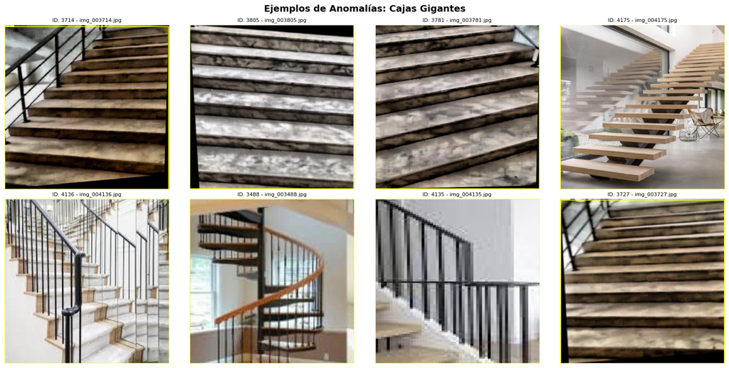

```python
# 25. Visualizar imágenes anómalas con cajas gigantes
if len(suspect_huge) > 0:
    print("\n Ejemplos de imágenes anómalas: con cajas gigantes")
    unique_huge_ids = list(set([s['img_id'] for s in suspect_huge]))
    sample_size = min(8, len(unique_huge_ids))  # Máximo 8 imágenes en grilla 4x2
    sample_huge = random.sample(unique_huge_ids, sample_size)

    # Usar grilla de visualize_sample para mostrar múltiples imágenes
    visualize_sample(coco, target_cat_ids, id_to_name, class_colors, img_dir,
                    img_ids=sample_huge, output_dir=output_dir, filename='25_anomaly_huge', title='Ejemplos de Anomalías: Cajas Gigantes')
```

## Síntesis del EDA: Dataset Indoor Obstacle Detection

La siguiente tabla resume los hallazgos críticos del Análisis Exploratorio de Datos, sus implicaciones técnicas para un sistema de navegación robótica basado en ESP32-S3 (TinyML) y las acciones correctivas definidas.

[output not shown]

**🎯 Conclusión Final:**

Para el **entrenamiento orientado a TinyML/ESP32-S3**, las principales consideraciones son:

- Usar **Focal Loss** y class weights para compensar desbalance.
- Establecer **max_detections ≤ 20** para acotar uso de memoria en inferencia.
- Priorizar **cabeza P5 (objetos grandes)** y simplificar/eliminar P3 (small objects) en la arquitectura.
- Incluir **imágenes background** (vacías) para reducir falsos positivos en navegación real.
- Entrenar con **progressive resizing** (640→320→192) para robustez a baja resolución.

# Preprocesado del Dataset

Esta sección del notebook se centra en la preparación de los datos para el entrenamiento del modelo de detección de objetos.

- **Paso 1:** Data Augmentation
- **Paso 2:** Split del Dataset (train/valid/test)
- **Paso 3:** Normalización de Imágenes (mean/std)
- **Paso 4:** Guardar el Dataset Preprocesado en Formato YOLO

## Paso 1: Data Augmentation (Análisis y Planificación)

Una vez identificadas las clases minoritarias en las fases anteriores, es momento de planificar la estrategia de **Data Augmentation** para balancear el dataset.

**Objetivos:**

1. **Identificar necesidades:** Calcular déficit de instancias por clase respecto a un objetivo.
2. **Planificar estrategia:** Determinar cuántas copias augmentadas generar por imagen candidata.
3. **Visualizar impacto:** Proyectar distribución ANTES vs DESPUÉS del augmentation.
4. **Ejecutar pipeline:** (Opcional) Integrar transformaciones de albumentations para generar dataset balanceado.

**Estrategias de Transformación:**

- **Mild (Suave):** HorizontalFlip, RandomBrightnessContrast, GaussNoise, GaussianBlur - para clases con déficit < 100 instancias.
- **Aggressive (Agresiva):** Affine (rotación, escala, traslación), ColorJitter, RandomGamma, MotionBlur - para clases altamente minoritarias.

**Nota:** El pipeline completo de augmentation se ejecuta mediante el script standalone `01_ING_DATOS/Datasets/Augmentation_dataset.py` que genera un nuevo dataset sin modificar el original.

```python
# --- ANÁLISIS DE NECESIDADES DE AUGMENTATION ---
# Definir objetivo de instancias por clase (ajustar según criterio)
# TARGET_INSTANCES = 400  # Valor objetivo para balanceo

# Analizar qué clases son minoritarias
# df_augmentation_analysis = analyze_augmentation_needs(coco, target_instances=TARGET_INSTANCES,
#                                                       output_dir=output_dir,
#                                                       filename='25_augmentation_analysis')
```

```python
# --- PLANIFICACIÓN DE ESTRATEGIA ---
# Calcular cuántas copias augmentadas se necesitan por imagen
# df_augmentation_plan = compute_augmentation_strategy(df_augmentation_analysis,
#                                                      output_dir=output_dir,
#                                                      filename='26_augmentation_plan')
```

```python
# --- VISUALIZACIÓN DEL IMPACTO ---
# Comparar distribución ANTES vs DESPUÉS (proyectado)
#if len(df_augmentation_plan) > 0:
#    visualize_augmentation_impact(df_augmentation_analysis, df_augmentation_plan,
#                                  output_dir=output_dir, filename='27_augmentation_impact')
#else:
#    print("\n✅ No se requiere visualización: dataset ya está balanceado")
```

**Ejecución del Pipeline de Augmentation**

Para ejecutar el pipeline completo de data augmentation con albumentations:

```
cd /Users/admin/Documents/TFM_UNIR/01_ING_DATOS/Datasets
python Augmentation_dataset.py
```

**El script realiza:**

1. Copia completa del dataset original a `dataset_maestro_aug/`
2. Identifica imágenes candidatas que contienen classes minoritarias
3. Aplica transformaciones mild/aggressive según el déficit
4. Genera imágenes augmentadas con sus anotaciones YOLO
5. Exporta:
   - `augmentation_log.csv`: Trazabilidad de imágenes generadas
   - `class_distribution.png`: Gráfico ANTES/DESPUÉS
   - `data.yaml`: Configuración actualizada

**Ventajas:**

- ✅ No modifica el dataset original
- ✅ Preserva formato YOLO (imágenes + labels .txt)
- ✅ Transformaciones bbox-aware (no corta objetos)
- ✅ Log completo de trazabilidad

## Paso 2: Split de Dataset

- **Comparación Multi-Split:**
  - **Objetivo:** Verificar que train/valid/test tengan distribuciones de clases similares (test Chi-cuadrado).

```python
# --- COMPARACIÓN DE DISTRIBUCIÓN ENTRE SPLITS ---
# NOTA: No aplica para el dataset unificado (no hay splits train/valid/test).
# Esta comparación se realizará después de dividir el dataset en splits para entrenamiento.
# print("⏭️  Comparación multi-split omitida: el dataset unificado no tiene splits.")
```

```python
# Test Chi-cuadrado para verificar homogeneidad estadística entre splits
# NOTA: No aplica para el dataset unificado (requiere múltiples splits).
# Se ejecutará después de dividir el dataset en splits para entrenamiento.
# print("⏭️  Test Chi-cuadrado omitido: requiere múltiples splits.")
```

```python
# Analizar distribución de imágenes y anotaciones por split
# df_split_dist = analyze_split_distribution(splits, output_dir=output_dir, filename='06_split_distribution')
```

## Paso 3: Guardar Dataset Preprocesado en Formato YOLO